# **The Evolution of Height in the NBA**

Collaborators: Brian Diarra, Obinna Anako, Tyler Krauth, Jesuseyi Oyeyemi

## **Introduction**

The [National Basketball Association (NBA)](https://www.nba.com/) is a men's professional basketball league in North America. It was founded in 1946, and since then has become one of the most popular sports leagues in the world. With millions of fans and followers, the NBA has produced some of the most iconic players in the history of the game. From the likes of Wilt Chamberlain to Shaquille O'Neal to LeBron James, the NBA has seen some of the greatest players of all time. One of the factors that have changed throughout the years in the NBA is the height of the players. In this tutorial, we will explore the evolution of height in the NBA, and how it has impacted the game.

**Motivation**

The main purpose of this project is to guide you through the entire pipeline of data science, focusing on the evolution of height in the NBA. Over the years, the game of basketball has evolved in many ways, with one notable aspect being the changing role of height in the sport. Tall players have gone from being primarily tough rebounders and shot blockers to exhibiting skills like shooting and playmaking, which were originally viewed as point guard and shooting guard specific skills, as seen in the rise of players like Victor Wembanyama. As height continues to play a significant role in the game, it's essential to understand its impact on the NBA landscape.

Why is this important? Analyzing the evolution of height in the NBA provides valuable insights into the changing dynamics of the sport. By understanding these changes, coaches, teams, and analysts can better adapt their strategies and develop more effective game plans. Moreover, such an analysis can also shed light on how the game has evolved in terms of athleticism and skill, ultimately enhancing the viewer experience for fans.

Throughout this tutorial, we will be going through the Data Science Lifecycle as follows:

1. Data Collection
2. Data Processing
3. Exploratory Analysis & Data Visualization
4. Model: Analysis, Hypothesis Testing, & ML
5. Interpretation: Insight & Policy Decision

## **Data Collection**

Data Collection Our first step in the data science life cycle is to search for a dataset that fits our topic. We need information on NBA players' heights, the years they played, and additional data that might be relevant, such as their positions and statistics.

The Kaggle platform, known for hosting a wide variety of datasets, provides us with an ideal source. We found a dataset named "NBA Players stats since 1950" at https://www.kaggle.com/drgilermo/nba-players-stats. This dataset is rich in detail and spans a good period, giving us enough data points to analyze the evolution of height in NBA players.

To download the dataset:

Visit the above link. Click on the “Download” button. Unzip the downloaded file and you will find three CSV files: player_data.csv, players.csv, and seasons_stats.csv. In this tutorial, we will be interested in all 3 files. Make sure to store the files file in your project directory.

During this project, we will be using the Python language, and we use tools such as IPython and Jupyter Notebook to develop this project. If you haven't heard about Jupyter notebooks before, make sure to learn more about them here.

To start any Python project, we need to import some libraries. Here are some of the libraries we will be using throughout this tutorial:

```python
import numpy as np
import pandas as pd
import os
import datetime
import seaborn as sns
import matplotlib.pyplot as plt
```

```python
players = pd.read_csv("Players.csv")
seasons_stats = pd.read_csv("Seasons_Stats.csv")
player_data = pd.read_csv("player_data.csv")
```

```python
players.head()
```

|  | Unnamed: 0 | Player | height | weight | collage | born | birth_city | birth_state |
| --- | --- | --- | --- | --- | --- | --- | --- | --- |
| 0 | 0 | Curly Armstrong | 180.0 | 77.0 | Indiana University | 1918.0 | NaN | NaN |
| 1 | 1 | Cliff Barker | 188.0 | 83.0 | University of Kentucky | 1921.0 | Yorktown | Indiana |
| 2 | 2 | Leo Barnhorst | 193.0 | 86.0 | University of Notre Dame | 1924.0 | NaN | NaN |
| 3 | 3 | Ed Bartels | 196.0 | 88.0 | North Carolina State University | 1925.0 | NaN | NaN |
| 4 | 4 | Ralph Beard | 178.0 | 79.0 | University of Kentucky | 1927.0 | Hardinsburg | Kentucky |

```python
seasons_stats.head()
```

|  | Unnamed: 0 | Year | Player | Pos | Age | Tm | G | GS | MP | PER | ... | FT% | ORB | DRB | TRB | AST | STL | BLK | TOV | PF | PTS |
| --- | --- | --- | --- | --- | --- | --- | --- | --- | --- | --- | --- | --- | --- | --- | --- | --- | --- | --- | --- | --- | --- |
| 0 | 0 | 1950.0 | Curly Armstrong | G-F | 31.0 | FTW | 63.0 | NaN | NaN | NaN | ... | 0.705 | NaN | NaN | NaN | 176.0 | NaN | NaN | NaN | 217.0 | 458.0 |
| 1 | 1 | 1950.0 | Cliff Barker | SG | 29.0 | INO | 49.0 | NaN | NaN | NaN | ... | 0.708 | NaN | NaN | NaN | 109.0 | NaN | NaN | NaN | 99.0 | 279.0 |
| 2 | 2 | 1950.0 | Leo Barnhorst | SF | 25.0 | CHS | 67.0 | NaN | NaN | NaN | ... | 0.698 | NaN | NaN | NaN | 140.0 | NaN | NaN | NaN | 192.0 | 438.0 |
| 3 | 3 | 1950.0 | Ed Bartels | F | 24.0 | TOT | 15.0 | NaN | NaN | NaN | ... | 0.559 | NaN | NaN | NaN | 20.0 | NaN | NaN | NaN | 29.0 | 63.0 |
| 4 | 4 | 1950.0 | Ed Bartels | F | 24.0 | DNN | 13.0 | NaN | NaN | NaN | ... | 0.548 | NaN | NaN | NaN | 20.0 | NaN | NaN | NaN | 27.0 | 59.0 |

5 rows × 53 columns

```python
player_data.head()
```

|  | name | year_start | year_end | position | height | weight | birth_date | college |
| --- | --- | --- | --- | --- | --- | --- | --- | --- |
| 0 | Alaa Abdelnaby | 1991 | 1995 | F-C | 6-10 | 240.0 | June 24, 1968 | Duke University |
| 1 | Zaid Abdul-Aziz | 1969 | 1978 | C-F | 6-9 | 235.0 | April 7, 1946 | Iowa State University |
| 2 | Kareem Abdul-Jabbar | 1970 | 1989 | C | 7-2 | 225.0 | April 16, 1947 | University of California, Los Angeles |
| 3 | Mahmoud Abdul-Rauf | 1991 | 2001 | G | 6-1 | 162.0 | March 9, 1969 | Louisiana State University |
| 4 | Tariq Abdul-Wahad | 1998 | 2003 | F | 6-6 | 223.0 | November 3, 1974 | San Jose State University |

```python
players= players.rename(columns={"Player": "name"})
seasons_stats = seasons_stats.rename(columns={"Player": "name"})
```

```python
season2017 =seasons_stats[seasons_stats.Year == 2017]
season2017 = season2017.groupby(['Year', 'name']).sum().reset_index()
season2017 =season2017.drop('Unnamed: 0', axis =1)
season2017.head()
```

|  | Year | name | Age | G | GS | MP | PER | TS% | 3PAr | FTr | ... | FT% | ORB | DRB | TRB | AST | STL | BLK | TOV | PF | PTS |
| --- | --- | --- | --- | --- | --- | --- | --- | --- | --- | --- | --- | --- | --- | --- | --- | --- | --- | --- | --- | --- | --- |
| 0 | 2017.0 | A.J. Hammons | 24.0 | 22.0 | 0.0 | 163.0 | 8.4 | 0.472 | 0.238 | 0.476 | ... | 0.450 | 8.0 | 28.0 | 36.0 | 4.0 | 1.0 | 13.0 | 10.0 | 21.0 | 48.0 |
| 1 | 2017.0 | Aaron Brooks | 32.0 | 65.0 | 0.0 | 894.0 | 9.5 | 0.507 | 0.427 | 0.133 | ... | 0.800 | 18.0 | 51.0 | 69.0 | 125.0 | 25.0 | 9.0 | 66.0 | 93.0 | 322.0 |
| 2 | 2017.0 | Aaron Gordon | 21.0 | 80.0 | 72.0 | 2298.0 | 14.4 | 0.530 | 0.309 | 0.251 | ... | 0.719 | 116.0 | 289.0 | 405.0 | 150.0 | 64.0 | 40.0 | 89.0 | 172.0 | 1019.0 |
| 3 | 2017.0 | Aaron Harrison | 22.0 | 5.0 | 0.0 | 17.0 | -2.2 | 0.102 | 0.500 | 0.500 | ... | 0.500 | 0.0 | 3.0 | 3.0 | 3.0 | 0.0 | 0.0 | 0.0 | 2.0 | 1.0 |
| 4 | 2017.0 | Adreian Payne | 25.0 | 18.0 | 0.0 | 135.0 | 14.4 | 0.505 | 0.278 | 0.352 | ... | 0.737 | 9.0 | 24.0 | 33.0 | 7.0 | 8.0 | 7.0 | 8.0 | 32.0 | 63.0 |

5 rows × 50 columns

```python
season1973 =seasons_stats[seasons_stats.Year == 1980] # changed
season1973 = season1973.groupby(['Year', 'name']).sum().reset_index()
season1973 = season1973.drop('Unnamed: 0', axis =1)
season1973.head()
```

|  | Year | name | Age | G | GS | MP | PER | TS% | 3PAr | FTr | ... | FT% | ORB | DRB | TRB | AST | STL | BLK | TOV | PF | PTS |
| --- | --- | --- | --- | --- | --- | --- | --- | --- | --- | --- | --- | --- | --- | --- | --- | --- | --- | --- | --- | --- | --- |
| 0 | 1980.0 | Abdul Jeelani | 25.0 | 77.0 | 0.0 | 1286.0 | 18.7 | 0.563 | 0.011 | 0.361 | ... | 0.789 | 114.0 | 156.0 | 270.0 | 95.0 | 40.0 | 40.0 | 117.0 | 155.0 | 737.0 |
| 1 | 1980.0 | Adrian Dantley* | 23.0 | 68.0 | 0.0 | 2674.0 | 24.3 | 0.635 | 0.002 | 0.415 | ... | 0.842 | 183.0 | 333.0 | 516.0 | 191.0 | 96.0 | 14.0 | 233.0 | 211.0 | 1903.0 |
| 2 | 1980.0 | Al Skinner | 27.0 | 2.0 | 0.0 | 10.0 | -0.6 | 0.500 | 0.000 | 0.000 | ... | 0.000 | 0.0 | 0.0 | 0.0 | 2.0 | 0.0 | 0.0 | 2.0 | 1.0 | 2.0 |
| 3 | 1980.0 | Alex English* | 78.0 | 156.0 | 0.0 | 4802.0 | 54.2 | 1.606 | 0.016 | 0.738 | ... | 2.365 | 538.0 | 672.0 | 1210.0 | 448.0 | 146.0 | 124.0 | 428.0 | 412.0 | 2636.0 |
| 4 | 1980.0 | Allan Bristow | 28.0 | 82.0 | 0.0 | 2304.0 | 16.6 | 0.534 | 0.009 | 0.310 | ... | 0.811 | 170.0 | 342.0 | 512.0 | 341.0 | 88.0 | 6.0 | 179.0 | 211.0 | 953.0 |

5 rows × 50 columns

Data Transformation

In the code above, "player" is the existing column name and "name" is the new column name. After running this code, the column originally named "player" in the players DataFrame will be renamed to "name".

This was done to allow merge Merging datasets allows us to combine relevant data from different sources into a single dataframe that we can analyze. We used an inner join to merge our datasets, which means that only the rows with matching 'name' values in both dataframes are included in the output.

```python
import numpy as np
import pandas as pd
import os
import datetime
import seaborn as sns
import matplotlib.pyplot as plt

players = pd.read_csv("Players.csv")
players= players.rename(columns={"Player": "name"})
merged_data = pd.merge( players,player_data, on='name', how='inner')
merged_data = merged_data.drop('height_y', axis=1)
merged_data = merged_data.drop('weight_y', axis=1)
#merged_data = merged_data.drop('id', axis=1)
merged_data = merged_data.drop('birth_city', axis=1)
merged_data = merged_data.drop('birth_state', axis=1)
merged_data["height_x"] = merged_data["height_x"]
merged_data.head()
```

|  | Unnamed: 0 | name | height_x | weight_x | collage | born | year_start | year_end | position | birth_date | college |
| --- | --- | --- | --- | --- | --- | --- | --- | --- | --- | --- | --- |
| 0 | 0 | Curly Armstrong | 180.0 | 77.0 | Indiana University | 1918.0 | 1949 | 1951 | G-F | November 1, 1918 | Indiana University |
| 1 | 1 | Cliff Barker | 188.0 | 83.0 | University of Kentucky | 1921.0 | 1950 | 1952 | G | January 15, 1921 | University of Kentucky |
| 2 | 2 | Leo Barnhorst | 193.0 | 86.0 | University of Notre Dame | 1924.0 | 1950 | 1954 | F-G | May 11, 1924 | University of Notre Dame |
| 3 | 3 | Ed Bartels | 196.0 | 88.0 | North Carolina State University | 1925.0 | 1950 | 1951 | F | October 8, 1925 | North Carolina State University |
| 4 | 4 | Ralph Beard | 178.0 | 79.0 | University of Kentucky | 1927.0 | 1950 | 1951 | G | December 2, 1927 | University of Kentucky |

```python
merged2017 = pd.merge( season2017, merged_data, on='name', how='inner')
#merged2017 = merged2017.drop('collage', axis=1)
#merged2017 = merged2017.drop('3PAr', axis=1)
#merged2017 = merged2017.drop('ORB%', axis=1)
#merged2017 = merged2017.drop('DRB%', axis=1)
#merged2017 = merged2017.drop('TS%', axis=1)
merged2017.head()
```

|  | Year | name | Age | G | GS | MP | PER | TS% | 3PAr | FTr | ... | Unnamed: 0 | height_x | weight_x | collage | born | year_start | year_end | position | birth_date | college |
| --- | --- | --- | --- | --- | --- | --- | --- | --- | --- | --- | --- | --- | --- | --- | --- | --- | --- | --- | --- | --- | --- |
| 0 | 2017.0 | A.J. Hammons | 24.0 | 22.0 | 0.0 | 163.0 | 8.4 | 0.472 | 0.238 | 0.476 | ... | 3863 | 198.0 | 99.0 | NaN | 1993.0 | 2017 | 2017 | C | August 27, 1992 | Purdue University |
| 1 | 2017.0 | Aaron Brooks | 32.0 | 65.0 | 0.0 | 894.0 | 9.5 | 0.507 | 0.427 | 0.133 | ... | 3211 | 183.0 | 73.0 | University of Oregon | 1985.0 | 2008 | 2018 | G | January 14, 1985 | University of Oregon |
| 2 | 2017.0 | Aaron Gordon | 21.0 | 80.0 | 72.0 | 2298.0 | 14.4 | 0.530 | 0.309 | 0.251 | ... | 3707 | 206.0 | 99.0 | University of Arizona | 1995.0 | 2015 | 2018 | F | September 16, 1995 | University of Arizona |
| 3 | 2017.0 | Aaron Harrison | 22.0 | 5.0 | 0.0 | 17.0 | -2.2 | 0.102 | 0.500 | 0.500 | ... | 3780 | 198.0 | 95.0 | University of Kentucky | 1994.0 | 2016 | 2017 | G | October 28, 1994 | University of Kentucky |
| 4 | 2017.0 | Adreian Payne | 25.0 | 18.0 | 0.0 | 135.0 | 14.4 | 0.505 | 0.278 | 0.352 | ... | 3742 | 208.0 | 107.0 | Michigan State University | 1991.0 | 2015 | 2018 | F-C | February 19, 1991 | Michigan State University |

5 rows × 60 columns

```python
merged1973 = pd.merge( season1973, merged_data, on='name', how='inner')
#merged1973 = merged1973.drop('collage', axis=1)
#merged1973 = merged1973.drop('3PAr', axis=1)
#merged1973 = merged1973.drop('ORB%', axis=1)
#merged1973 = merged1973.drop('DRB%', axis=1)
#merged1973 = merged1973.drop('TS%', axis=1)
merged1973.head()
```

|  | Year | name | Age | G | GS | MP | PER | TS% | 3PAr | FTr | ... | Unnamed: 0 | height_x | weight_x | collage | born | year_start | year_end | position | birth_date | college |
| --- | --- | --- | --- | --- | --- | --- | --- | --- | --- | --- | --- | --- | --- | --- | --- | --- | --- | --- | --- | --- | --- |
| 0 | 1980.0 | Abdul Jeelani | 25.0 | 77.0 | 0.0 | 1286.0 | 18.7 | 0.563 | 0.011 | 0.361 | ... | 1364 | 203.0 | 95.0 | University of Wisconsin-Parkside | 1954.0 | 1980 | 1981 | F-C | February 10, 1954 | University of Wisconsin-Parkside |
| 1 | 1980.0 | Al Skinner | 27.0 | 2.0 | 0.0 | 10.0 | -0.6 | 0.500 | 0.000 | 0.000 | ... | 1206 | 190.0 | 86.0 | University of Massachusetts Amherst | 1952.0 | 1975 | 1980 | G | June 16, 1952 | University of Massachusetts Amherst |
| 2 | 1980.0 | Allan Bristow | 28.0 | 82.0 | 0.0 | 2304.0 | 16.6 | 0.534 | 0.009 | 0.310 | ... | 981 | 201.0 | 95.0 | Virginia Polytechnic Institute and State Unive... | 1951.0 | 1974 | 1983 | F-G | August 23, 1951 | Virginia Polytechnic Institute and State Unive... |
| 3 | 1980.0 | Allen Leavell | 22.0 | 77.0 | 0.0 | 2123.0 | 15.1 | 0.560 | 0.029 | 0.337 | ... | 1374 | 185.0 | 77.0 | Oklahoma City University | 1957.0 | 1980 | 1989 | G | May 27, 1957 | Oklahoma City University |
| 4 | 1980.0 | Alonzo Bradley | 26.0 | 22.0 | 0.0 | 96.0 | 4.1 | 0.395 | 0.021 | 0.188 | ... | 1236 | 198.0 | 86.0 | Texas Southern University | 1953.0 | 1978 | 1980 | F | October 16, 1953 | Texas Southern University |

5 rows × 60 columns

Data Cleaning

we could have done this for all the data sets above but ive chose to clean only 2 data sets since those are the only data sets ill use from now on. Firstly, we need to check if our data contains missing values. We can use the isnull().sum() function in pandas to identify columns with missing data:

```python
print(merged2017.isnull().sum())
```

[output not shown]

This will return the number of missing values in each column. If there are missing values, we need to decide how to handle them. For instance, we might drop rows with missing data, or we might fill in missing values with the mean or median of that column:

```python
merged2017['height_x'].fillna(merged2017['height_x'].mean(), inplace=True)
```

Data Exploration

```python
print("2017 Season Summary Statistics:\n", merged2017['height_x'].describe())
print("\n1980 Season Summary Statistics:\n", merged1973['height_x'].describe())
```

[output not shown]

histograms to visualize the height distributions, with the sns.histplot() function. The histograms allow us to see how the height distribution has changed over time, as well as any differences between the two seasons.

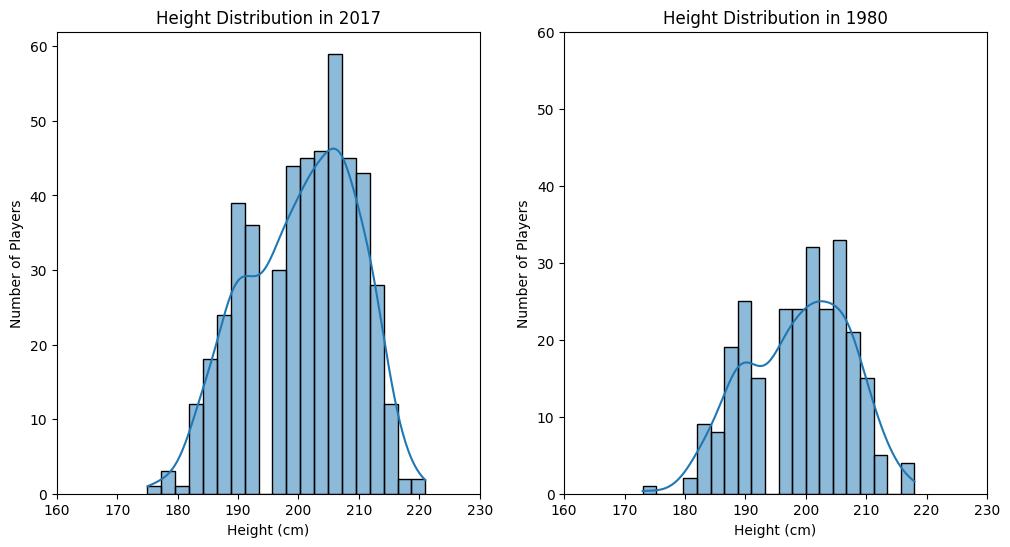

```python
plt.figure(figsize=(12, 6))
plt.subplot(1, 2, 1)
sns.histplot(data=merged2017, x="height_x", kde=True, bins=20).set_title('Height Distribution in 2017')
plt.xlabel("Height (cm)")
plt.ylabel("Number of Players")
plt.xticks(np.arange(160,231,10))
plt.yticks(np.arange(0,70,10))
plt.subplot(1, 2, 2)
sns.histplot(data=merged1973, x="height_x", kde=True, bins=20).set_title('Height Distribution in 1980')
plt.xlabel("Height (cm)")
plt.ylabel("Number of Players")
plt.xticks(np.arange(160,231,10))
plt.yticks(np.arange(0,70,10))
plt.show()
```

```python
print(merged1973.height_x.mean())
print(merged2017.height_x.mean())
```

```
198.84674329501917
200.5734693877551
```

```python
from scipy import stats
import statsmodels.formula.api as smf

mean_data = pd.merge( player_data,seasons_stats, on='name', how='inner')
#current_mean_data.Year

#europeData = merged_data.loc[merged_data['year'] == 1980]
#europeYears = np.array(europeData['year']).reshape(-1,1)
#model2 = LinearRegression().fit(europeYears, europeData['lifeExp'])
#plib.scatter(x = europeData["year"],y = europeData["lifeExp"], label="Europe")
#plib.plot(data["year"],model2.predict(years))
```

[output not shown]

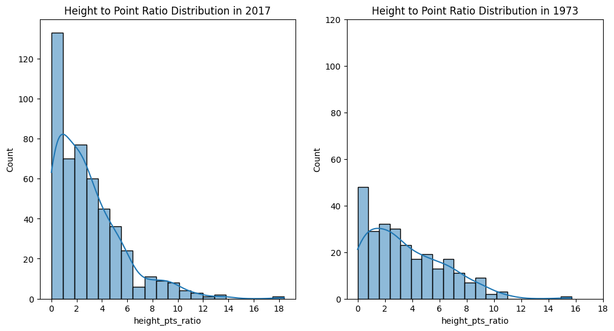

```python
merged2017['height_pts_ratio'] = merged2017['PTS'] / merged2017['height_x']
merged1973['height_pts_ratio'] = merged1973['PTS'] / merged1973['height_x']

plt.figure(figsize=(12, 6))
plt.subplot(1, 2, 1)
sns.histplot(data=merged2017, x="height_pts_ratio", kde=True, bins=20).set_title('Height to Point Ratio Distribution in 2017')
plt.xticks(np.arange(0,20,2))
plt.yticks(np.arange(0,140,20))
plt.subplot(1, 2, 2)
sns.histplot(data=merged1973, x="height_pts_ratio", kde=True, bins=20).set_title('Height to Point Ratio Distribution in 1973')
plt.xticks(np.arange(0,20,2))
plt.yticks(np.arange(0,140,20))
plt.show()
```

[output not shown]

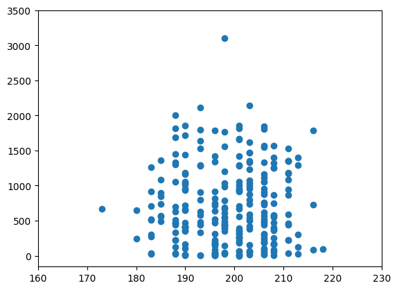

```python
#sns.boxplot(x=merged2017["height_x"], y=merged2017["PTS"])
plt.scatter(merged1973['height_x'], merged1973['PTS'])
#plt.xticks(np.arange(150,300,20))
plt.yticks(np.arange(0,4000,500))
plt.xticks(np.arange(160,240,10))
```

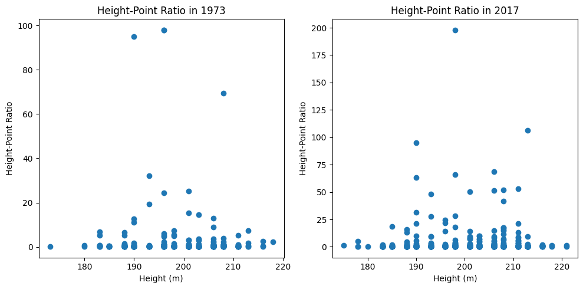

```python
merged2017['height_point_ratio'] = merged2017['height_x'] / merged2017['PTS']
merged1973['height_point_ratio'] = merged1973['height_x'] / merged1973['PTS']

plt.figure(figsize=(10, 5))

plt.subplot(1, 2, 1)
plt.scatter(merged1973['height_x'], merged1973['height_point_ratio'])
plt.xlabel('Height (m)')
plt.ylabel('Height-Point Ratio')
plt.title('Height-Point Ratio in 1973')

plt.subplot(1, 2, 2)
plt.scatter(merged2017['height_x'], merged2017['height_point_ratio'])
plt.xlabel('Height (m)')
plt.ylabel('Height-Point Ratio')
plt.title('Height-Point Ratio in 2017')

plt.tight_layout()
plt.show()
```

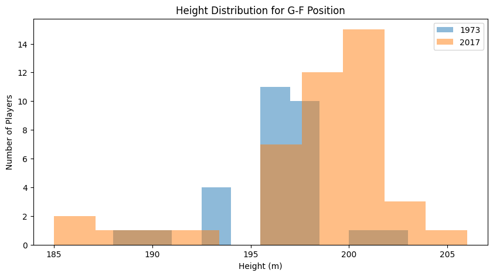

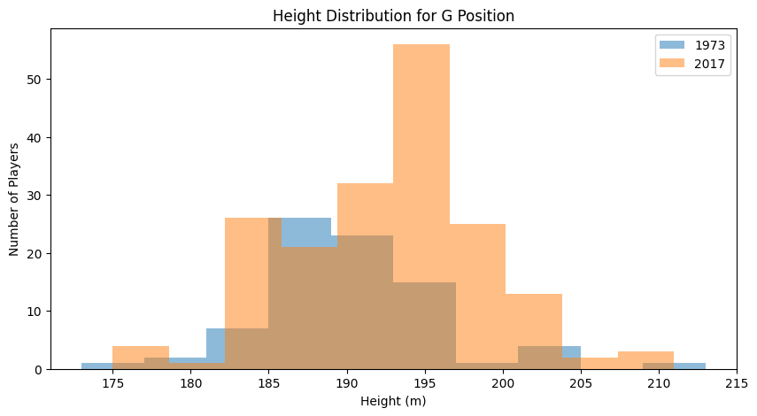

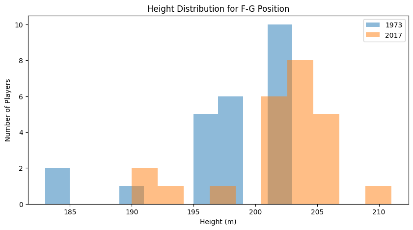

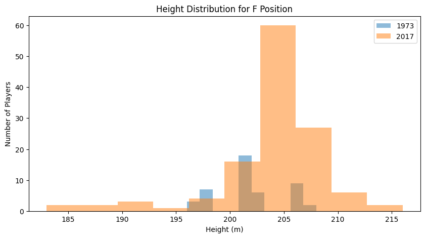

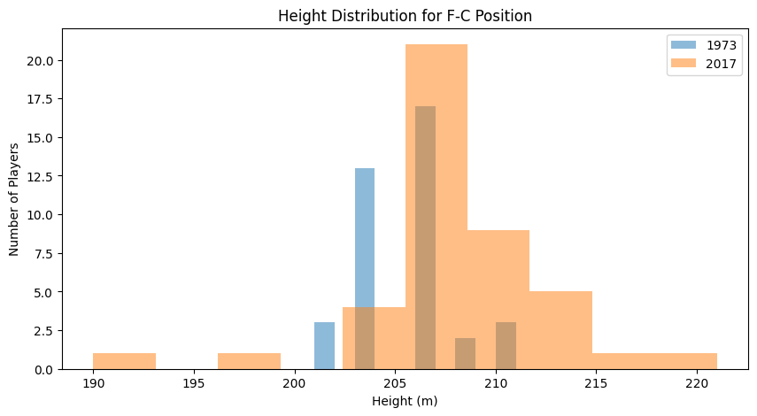

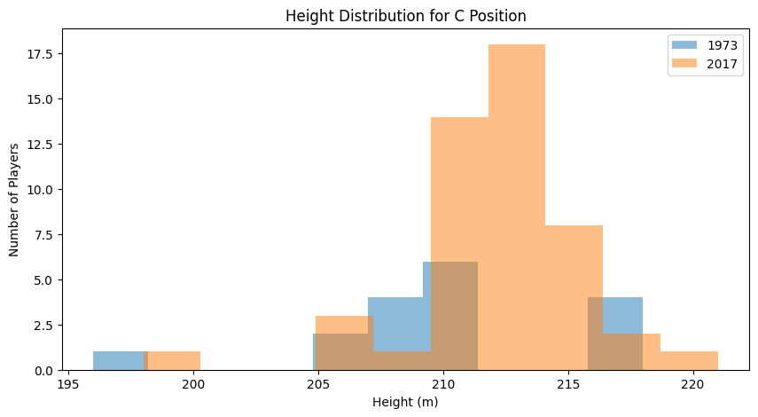

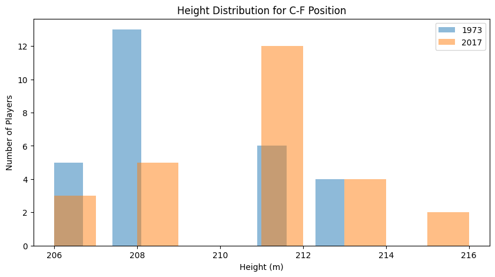

```python
positions = merged_data['position'].unique()
for pos in positions:
    if not pd.isna(pos):
        subset_1973 = merged1973[merged1973['position'] == pos]
        subset_2017 = merged2017[merged2017['position'] == pos]
        plt.figure(figsize=(10, 5))
        plt.hist(subset_1973['height_x'], bins=10, alpha=0.5, label='1973')
        plt.hist(subset_2017['height_x'], bins=10, alpha=0.5, label='2017')
        plt.title(f'Height Distribution for {pos} Position')
        plt.xlabel('Height (m)')
        plt.ylabel('Number of Players')
        plt.legend(loc='upper right')
        plt.show()
```

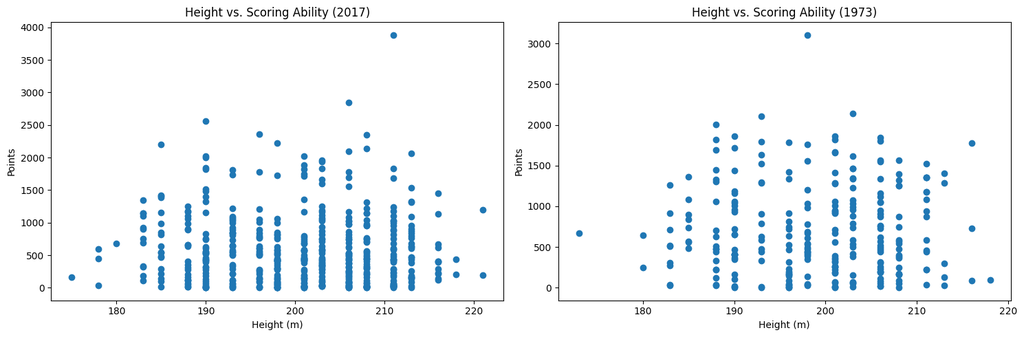

```python
fig, axs = plt.subplots(1, 2, figsize=(15, 5)) # 1 row, 2 columns

# Plot for 2017
axs[0].scatter(merged2017['height_x'], merged2017['PTS'])
axs[0].set_xlabel('Height (m)')
axs[0].set_ylabel('Points')
axs[0].set_title('Height vs. Scoring Ability (2017)')

# Plot for 1973
axs[1].scatter(merged1973['height_x'], merged1973['PTS'])
axs[1].set_xlabel('Height (m)')
axs[1].set_ylabel('Points')
axs[1].set_title('Height vs. Scoring Ability (1973)')

# Display the plots
plt.tight_layout()
plt.show()
```

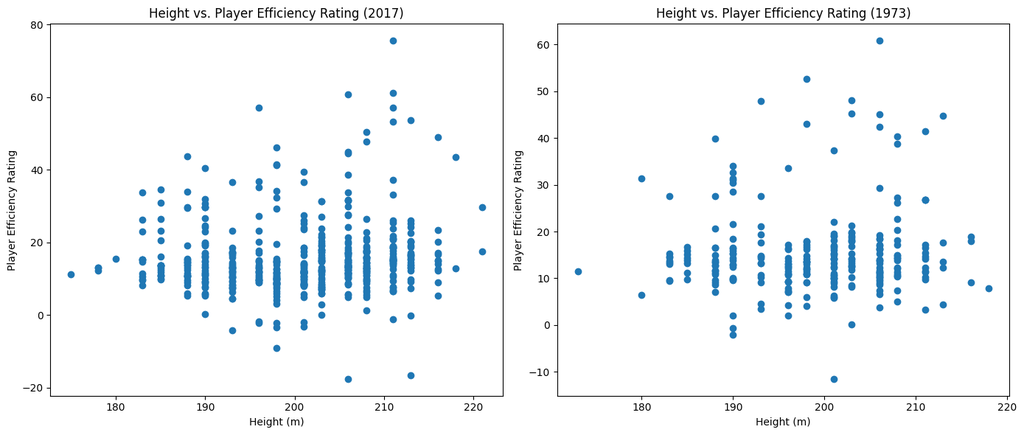

```python
fig, axs = plt.subplots(1, 2, figsize=(14, 6))  # 1 row, 2 columns

# Plot for 2017
axs[0].scatter(merged2017['height_x'], merged2017['PER'])
axs[0].set_xlabel('Height (m)')
axs[0].set_ylabel('Player Efficiency Rating')
axs[0].set_title('Height vs. Player Efficiency Rating (2017)')

# Plot for 1973
axs[1].scatter(merged1973['height_x'], merged1973['PER'])
axs[1].set_xlabel('Height (m)')
axs[1].set_ylabel('Player Efficiency Rating')
axs[1].set_title('Height vs. Player Efficiency Rating (1973)')

plt.tight_layout()
plt.show()
```

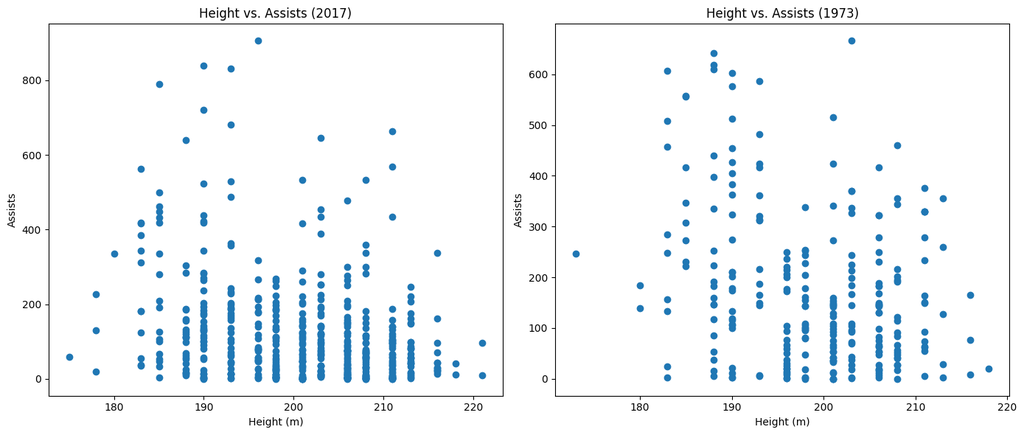

```python
plt.figure(figsize=(14,6))

# plot for 2017
plt.subplot(1, 2, 1) # the figure has 1 row, 2 columns, and this plot is the first plot.
plt.scatter(merged2017['height_x'], merged2017['AST'])
plt.xlabel('Height (m)')
plt.ylabel('Assists')
plt.title('Height vs. Assists (2017)')

# plot for 1973
plt.subplot(1, 2, 2) # the figure has 1 row, 2 columns, and this plot is the second plot.
plt.scatter(merged1973['height_x'], merged1973['AST'])
plt.xlabel('Height (m)')
plt.ylabel('Assists')
plt.title('Height vs. Assists (1973)')

plt.tight_layout()
plt.show()
```

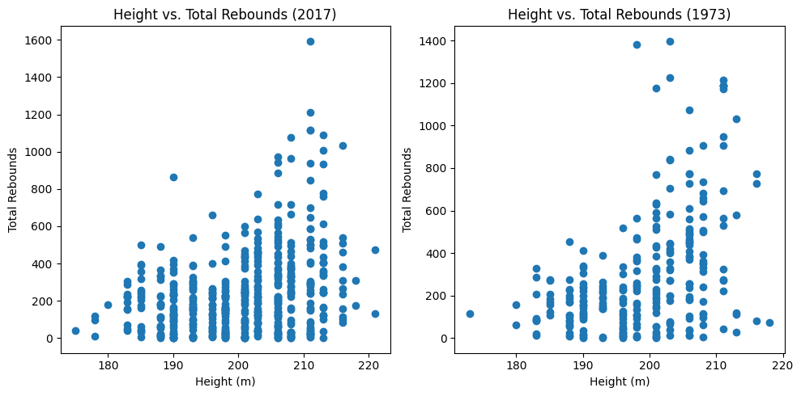

```python
# create a figure with two subplots side-by-side
fig, axs = plt.subplots(1, 2, figsize=(10, 5))

# plot the first subplot (2017)
axs[0].scatter(merged2017['height_x'], merged2017['TRB'])
axs[0].set_xlabel('Height (m)')
axs[0].set_ylabel('Total Rebounds')
axs[0].set_title('Height vs. Total Rebounds (2017)')

# plot the second subplot (1973)
axs[1].scatter(merged1973['height_x'], merged1973['TRB'])
axs[1].set_xlabel('Height (m)')
axs[1].set_ylabel('Total Rebounds')
axs[1].set_title('Height vs. Total Rebounds (1973)')

# adjust spacing between subplots and display the figure
fig.tight_layout()
plt.show()
```

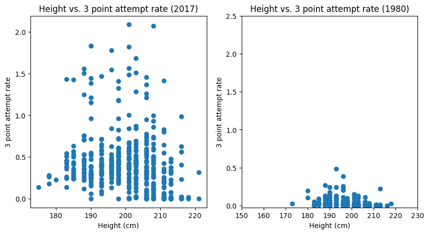

```python
# create a figure with two subplots side-by-side
fig, axs = plt.subplots(1, 2, figsize=(10, 5))

# plot the first subplot (2017)
axs[0].scatter(merged2017['height_x'], merged2017['3PAr'])
axs[0].set_xlabel('Height (cm)')
axs[0].set_ylabel('3 point attempt rate')
axs[0].set_title('Height vs. 3 point attempt rate (2017)')
plt.xticks(np.arange(150,240,10))
plt.yticks(np.arange(0,3,0.5))

# plot the second subplot (1973)
axs[1].scatter(merged1973['height_x'], merged1973['3PAr'])
axs[1].set_xlabel('Height (cm)')
axs[1].set_ylabel('3 point attempt rate')
axs[1].set_title('Height vs. 3 point attempt rate (1980)')
plt.xticks(np.arange(150,240,10))
plt.yticks(np.arange(0,3,0.5))

# adjust spacing between subplots and display the figure
#fig.tight_layout()
plt.show()
```